# Projekt Zed elektrownia

Bartosz Markowski

09 grudzień, 2017

## Podsumowanie

W wczytanych danych był0o bardzowiele atrybutów nic nie wnoszących do analizy, zostały one odrzucone na podstawie korelacji, która praktycznie nie występowała. Dwa atrybuty irradiamento oraz irr_pvgis_mod były ze sobą mocno skorelowane, dlatego postanowiłem pozbyć się irr_pvgis_mod ,ponieważ on miał mniejszą korelacje. Na podsawie wykresu z korelacją i przyjrzeniu się wartości do analizyw zostały wybrane atrybuty: idsito, irradiamento, altitude, humidity, tempi, irri, dist, azimuthi. Podczas analizy danych zauważyłem, że atrybuty kwh i irradiamento posiadają dużo wartości 0, dlatego na podstawie sredniej w miesiącu z danej godziny zostały one zastąpione. Jednak niektórych nie dudało się zastąpić ponieważ były z godzin nocnych, dlatego postanowiłem usunąć te dane.

## Biblioteki

```r
library(dplyr)
library(corrplot)
library('caret')
library(gridExtra)
library(ggplot2)
library(plotly)
```

## Powtarzalnośc

```r
set.seed(12)
```

## Wczytanie danych

```r
data <- read.csv('elektrownie.csv')
data <- data %>% mutate(month= format(as.POSIXct(data, format='%m/%d/%Y %H:%M'), "%Y-%m"))
data <- data %>% mutate(hour= as.numeric(format(as.POSIXct(data, format='%m/%d/%Y %H:%M'), "%H")))
```

## Brakujące dane

```r
meanIrradiamento <- data %>% filter(irradiamento != 0) %>% group_by(month, hour) %>% summarise(mean = mean(irradiamento))
meanKwh <- data %>% filter(kwh != 0) %>% group_by(month, hour) %>% summarise(mean = mean(kwh))

data <- data %>% mutate(irradiamento = ifelse(irradiamento != 0,
                                      irradiamento,
                                      as.numeric(meanIrradiamento[meanIrradiamento$hour == hour & meanIrradiamento$month == month,]$mean)
                                              )) %>% filter(!is.na(irradiamento))
data <- data %>% mutate(kwh = ifelse(kwh != 0,
                                      kwh,
                                      as.numeric(meanKwh[meanKwh$hour == hour & meanKwh$month == month,]$mean)
                                              )) %>% filter(!is.na(kwh))
```

## Podstawowe statystyki

```r
#liczba wierzy
len <- nrow(data)
print(len)
```

```
## [1] 151662
```

```r
#liczba kolumn
clen <- ncol(data)
print(clen)
```

```
## [1] 53
```

```r
iData <- data %>% select(irradiamento, altitude,humidity,tempi,irri,dist,azimuthi)
iData%>% summary()
```

```
##   irradiamento       altitude         humidity          tempi
##  Min.   :0.0010   Min.   :0.2510   Min.   :0.1600   Min.   :0.0310
##  1st Qu.:0.0420   1st Qu.:0.4800   1st Qu.:0.4800   1st Qu.:0.0730
##  Median :0.1490   Median :0.6230   Median :0.6300   Median :0.1130
##  Mean   :0.1689   Mean   :0.6036   Mean   :0.6307   Mean   :0.1322
##  3rd Qu.:0.2750   3rd Qu.:0.7340   3rd Qu.:0.7800   3rd Qu.:0.1420
##  Max.   :0.7100   Max.   :0.8840   Max.   :1.0000   Max.   :0.9830
##       irri             dist           azimuthi
##  Min.   :0.1080   Min.   :0.0000   Min.   :0.0460
##  1st Qu.:0.2160   1st Qu.:0.1530   1st Qu.:0.2070
##  Median :0.2180   Median :0.3880   Median :0.2480
##  Mean   :0.2232   Mean   :0.4220   Mean   :0.2939
##  3rd Qu.:0.2230   3rd Qu.:0.6557   3rd Qu.:0.3380
##  Max.   :1.0000   Max.   :1.0000   Max.   :0.8600
```

## Rozkład wybranych atrybutów

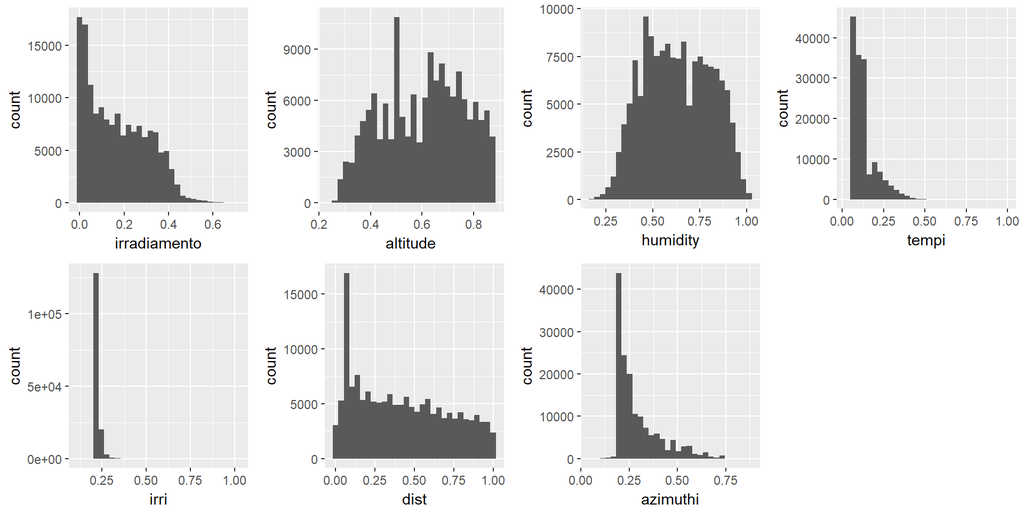

```r
array <- list()
for (col in colnames(iData)) {
array[[col]] <-((ggplot(iData) +
    aes_string(x=col) +
    geom_histogram(bins = 30)))
}

do.call(grid.arrange,c(array, ncol = 4))
```

## Korelacja miedzy atrybutami

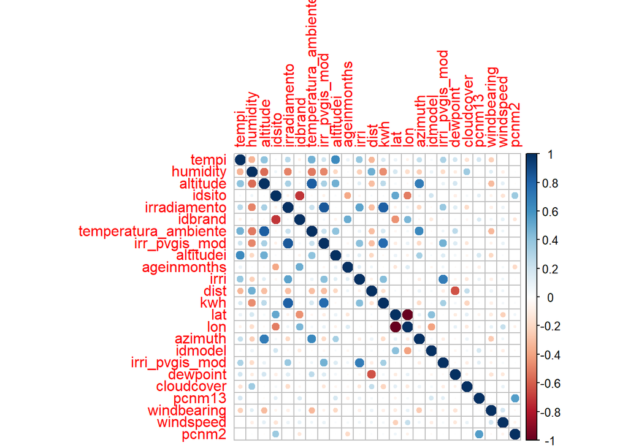

```r
data %>% select(-data, -month, -hour) %>% cor() ->corr
corr %>% findCorrelation(cutoff = 0.2) -> result
corrplot(corr[result,result])
```

## Interaktywny wykres

```r
plotData <- data %>% group_by(idsito, month) %>% summarise(kwh=sum(kwh))
plot <- ggplot(data = plotData, aes(month,kwh, color=factor(idsito))) +
  geom_point() +
  theme(axis.text.x = element_text(angle = 90))

ggplotly(plot)
```

```
## We recommend that you use the dev version of ggplot2 with `ggplotly()`
## Install it with: `devtools::install_github('hadley/ggplot2')`
```

[interactive chart not shown]

## Tworzenie regesora

```r
lernData <- data %>% select(idsito, irradiamento, altitude,humidity,tempi,irri,dist,azimuthi, kwh)
train <- createDataPartition(y=lernData$idsito, p = 0.7, list = F)
trainData <- lernData[train,]
testData <- lernData[-train,]


model <- train(
    kwh ~ .,
    data = trainData,
    method = "lm",
    metric = "RMSE",
    trControl = trainControl(method="repeatedcv",number = 2, repeats = 6)
)
test <- predict(model, newdata = testData);
postResample(test, testData$kwh)
```

```
##       RMSE   Rsquared        MAE
## 0.11557550 0.70221024 0.08068235
```

## Analiza regresora

```r
model %>% summary()
```

```
##
## Call:
## lm(formula = .outcome ~ ., data = dat)
##
## Residuals:
##      Min       1Q   Median       3Q      Max
## -0.66291 -0.05493 -0.00511  0.05482  1.08921
##
## Coefficients:
##               Estimate Std. Error t value Pr(>|t|)
## (Intercept)   0.212350   0.007403  28.684   <2e-16 ***
## idsito        0.134921   0.002751  49.049   <2e-16 ***
## irradiamento  1.196867   0.004242 282.128   <2e-16 ***
## altitude     -0.066853   0.002945 -22.699   <2e-16 ***
## humidity     -0.207680   0.002837 -73.210   <2e-16 ***
## tempi        -0.101621   0.006288 -16.161   <2e-16 ***
## irri          0.072355   0.031758   2.278   0.0227 *
## dist          0.066441   0.001646  40.362   <2e-16 ***
## azimuthi     -0.156943   0.004289 -36.588   <2e-16 ***
## ---
## Signif. codes:  0 '***' 0.001 '**' 0.01 '*' 0.05 '.' 0.1 ' ' 1
##
## Residual standard error: 0.1159 on 106156 degrees of freedom
## Multiple R-squared:  0.7023, Adjusted R-squared:  0.7022
## F-statistic: 3.13e+04 on 8 and 106156 DF,  p-value: < 2.2e-16
```